# Axe 2 - La participation sociale et le vivre-ensemble

Curbcut

# Axe 2 - La participation sociale et le vivre-ensemble

## Mixité sociale

Pour calculer la mixité sociale, nous avons utilisé des données du recensement pour cinq grandes dimensions : les catégories socioprofessionnelles, les origines ethniques et culturelles, les tranches d’âge, les niveaux de revenu et les niveaux d’éducation.

- Définition: Mixité sociale
  - La mixité (parfois appelée diversité) sociale réfère à la présence simultanée ou la cohabitation, en un même secteur géographique, de personnes appartenant à des catégories socioprofessionnelles, à des cultures, à des nationalités, à des tranches d’âge différentes. Cette notion, appliquée à un milieu de vie (un quartier par exemple), suppose une forme d’hétérogénéité en opposition avec des milieux de vie homogènes destinés à une proportion restreinte de la population (communauté ou classe sociale précise).[^1]

Pour évaluer la mixité sociale dans chaque zone, nous utilisons la méthode de l’entropie de Shannon. Cette méthode mesure à la fois la richesse des catégories (le nombre de groupes différents) et leur uniformité (comment les individus sont répartis entre ces groupes). Pour chaque dimension mentionnée ci-dessus, la formule attribue une valeur plus élevée lorsque les proportions des catégories, par exemple les niveaux d’éducation, sont plus uniformément réparties. Si tous les individus d’une zone appartiennent à la même origine ethnique ou culturelle, l’indice d’entropie sera de zéro. Une zone avec une répartition plus équilibrée des individus entre différentes catégories aura une entropie plus élevée, indiquant une plus grande mixité sociale.

MÉTHODOLOGIE NOTES DE FIN: Afin d’éviter que certaines dimensions ne dominent les autres, nous normalisons les valeurs pour chaque dimension. Cela garantit que chaque dimension contribue de manière égale à la mesure globale de la mixité sociale. Après normalisation, nous additionnons les entropies normalisées pour obtenir un indice composite de la mixité sociale dans chaque zone. Toutefois, même si chaque dimension est normalisée, une dimension particulière peut tout de même avoir un impact significatif sur l’indice composite si elle présente une diversité beaucoup plus marquée. Par exemple, une zone peut avoir une diversité culturelle exceptionnellement élevée qui influence fortement l’indice composite, même après normalisation.

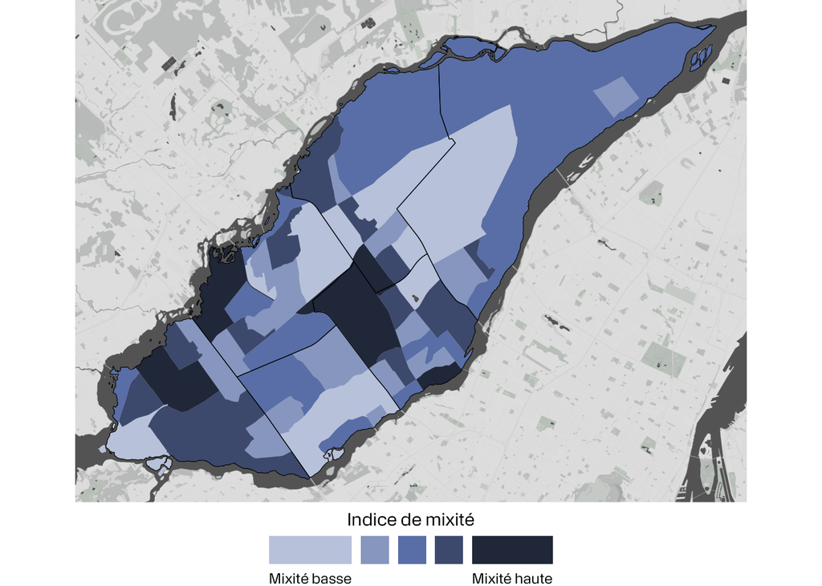

Indice de mixité sociale composite à Laval

Les figures en facettes montrent la mixité pour chaque dimension individuelle. Ces cartes permettent de visualiser les variations spécifiques à chaque dimension et d’identifier les zones où certaines formes de diversité sont plus ou moins présentes. Par exemple, on retrouve, au nord-est du secteur Vimont, Auteuil une haute mixité en terme de revenu et d’occupation professionnelle, mais une faible diversité en termes d’origines ethniques ou culturelles et de niveaux d’éducation. L’examination de chaque dimension séparément nous offre une compréhension plus nuancée et détaillée de la mixité sociale sur le territoire lavallois.

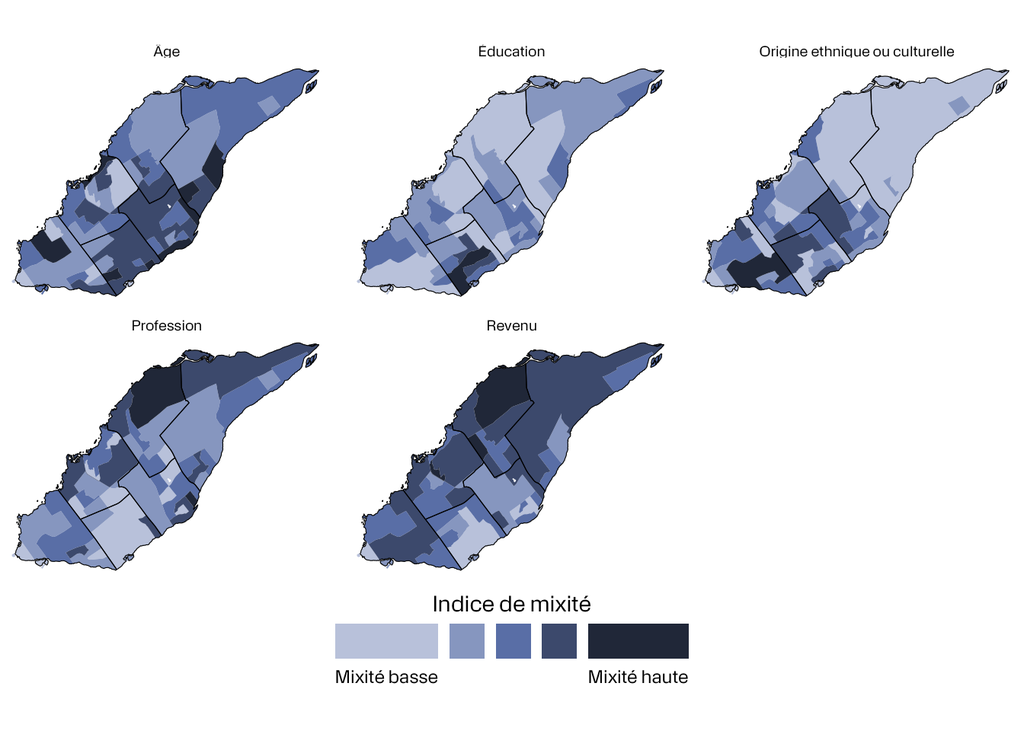

[^1]: Collectivitesviables.org. (2024). Mixité sociale. Récupéré de https://collectivitesviables.org/sujets/mixite-sociale/